# Practical D

Anne Vinkel (adapted from Gerko Vink)

Statistical Programming with R

We use the following packages:

```r
library(mice)
library(dplyr)
library(magrittr)
library(DAAG)
```

The following table shows numbers of occasions when inhibition (i.e., no flow of current across a membrane) occurred within 120 s, for different concentrations of the protein peptide-C. The outcome `yes` implies that inhibition has occurred.

```
conc 0.1 0.5  1 10 20 30 50 70 80 100 150
no     7   1 10  9  2  9 13  1  1   4   3
yes    0   0  3  4  0  6  7  0  0   1   7
```

1. **Create this data in `R`**

```r
data <- data.frame(conc = c(.1, .5, 1, 10, 20, 30, 50, 70, 80, 100, 150),
                   no = c(7, 1, 10, 9, 2, 9, 13, 1, 1, 4, 3),
                   yes = c(0, 0, 3, 4, 0, 6, 7, 0, 0, 1 ,7))
data
```

```
##     conc no yes
## 1    0.1  7   0
## 2    0.5  1   0
## 3    1.0 10   3
## 4   10.0  9   4
## 5   20.0  2   0
## 6   30.0  9   6
## 7   50.0 13   7
## 8   70.0  1   0
## 9   80.0  1   0
## 10 100.0  4   1
## 11 150.0  3   7
```

2. **Add two new variables (columns) to the data**
- the margin of `no` and `yes` over the rows (i.e. `no` + `yes`)
- the proportion (`yes` over `margin`)

```r
data <-
  data %>%
  mutate(margin = no+yes,
         prop = yes / margin)
```

3. **Fit the logistic model with `margin` as the weights**

```r
fit <-
  data %$%
  glm(prop ~ conc, family=binomial, weights=margin)
```

4. **Look at the summary of the fitted object**

```r
summary(fit)
```

```
##
## Call:
## glm(formula = prop ~ conc, family = binomial, weights = margin)
##
## Deviance Residuals:
##     Min       1Q   Median       3Q      Max
## -1.8159  -1.0552  -0.6878   0.3667   1.0315
##
## Coefficients:
##             Estimate Std. Error z value Pr(>|z|)
## (Intercept) -1.32701    0.33837  -3.922 8.79e-05 ***
## conc         0.01215    0.00496   2.450   0.0143 *
## ---
## Signif. codes:  0 '***' 0.001 '**' 0.01 '*' 0.05 '.' 0.1 ' ' 1
##
## (Dispersion parameter for binomial family taken to be 1)
##
##     Null deviance: 16.683  on 10  degrees of freedom
## Residual deviance: 10.389  on  9  degrees of freedom
## AIC: 30.988
##
## Number of Fisher Scoring iterations: 4
```

5. **Inspect the plots number 1 and 5 for `fit`**

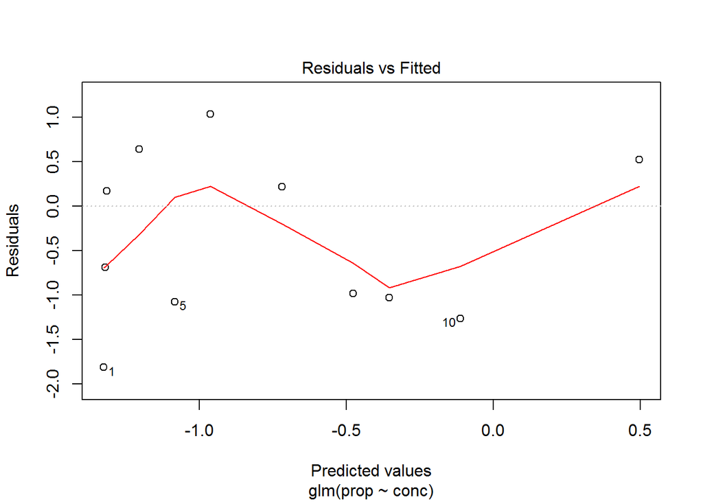

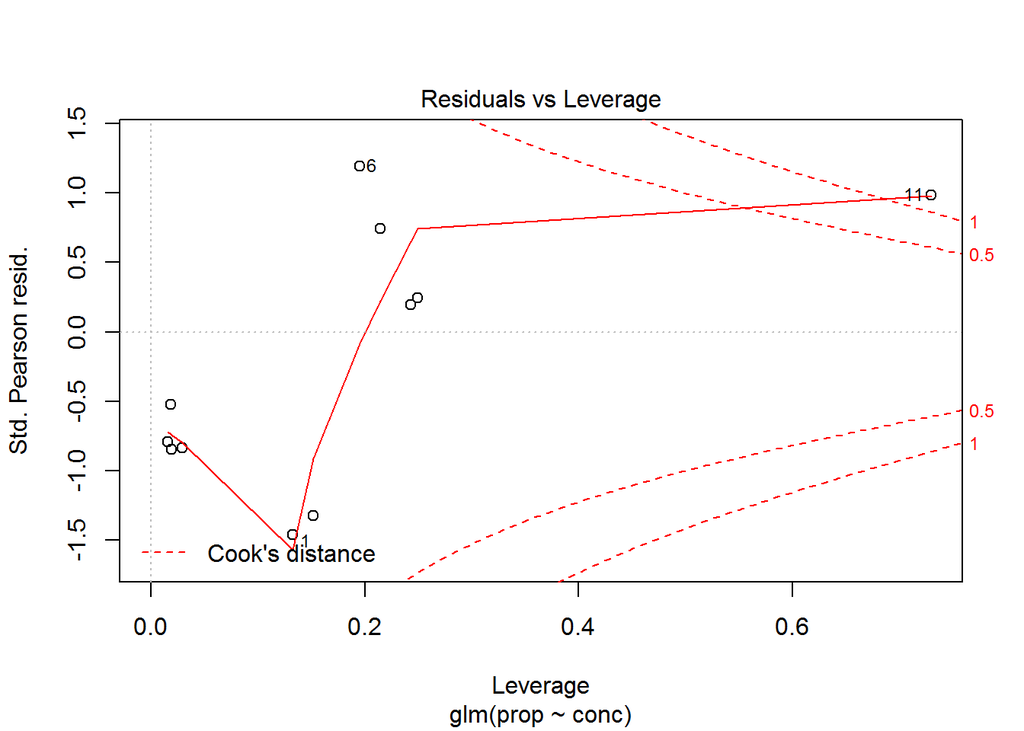

```r
plot(fit, which = c(1, 5))
```

The data set is small, but case `11` stands out in the `Residuals vs. Leverage` plot

6. **`conc` is somewhat skewed. Run the model again with a log-transformation for `conc`.**

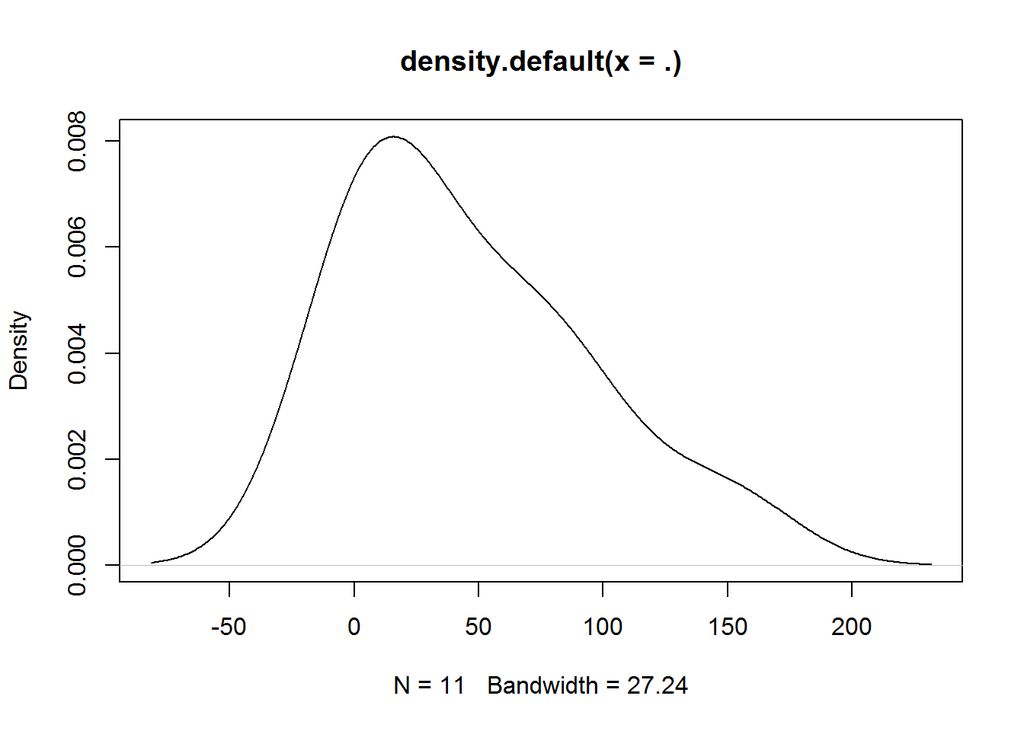

To apply this in the model directly:

```r
fit.log <-
  data %$%
  glm(prop ~ I(log(conc)), family=binomial, weights=margin)
```

7. **Look at the summary of the fitted object again**

```r
summary(fit.log)
```

```
##
## Call:
## glm(formula = prop ~ I(log(conc)), family = binomial, weights = margin)
##
## Deviance Residuals:
##     Min       1Q   Median       3Q      Max
## -1.2510  -1.0599  -0.5029   0.3152   1.3513
##
## Coefficients:
##              Estimate Std. Error z value Pr(>|z|)
## (Intercept)   -1.7659     0.5209  -3.390 0.000699 ***
## I(log(conc))   0.3437     0.1440   2.387 0.016975 *
## ---
## Signif. codes:  0 '***' 0.001 '**' 0.01 '*' 0.05 '.' 0.1 ' ' 1
##
## (Dispersion parameter for binomial family taken to be 1)
##
##     Null deviance: 16.6834  on 10  degrees of freedom
## Residual deviance:  9.3947  on  9  degrees of freedom
## AIC: 29.994
##
## Number of Fisher Scoring iterations: 4
```

The logodds now depict the unit increase in `log(conc)`, instead of `conc`.

8. **Inspects the plots number 1 and 5 of the fitted object based on `log(conc)`.**

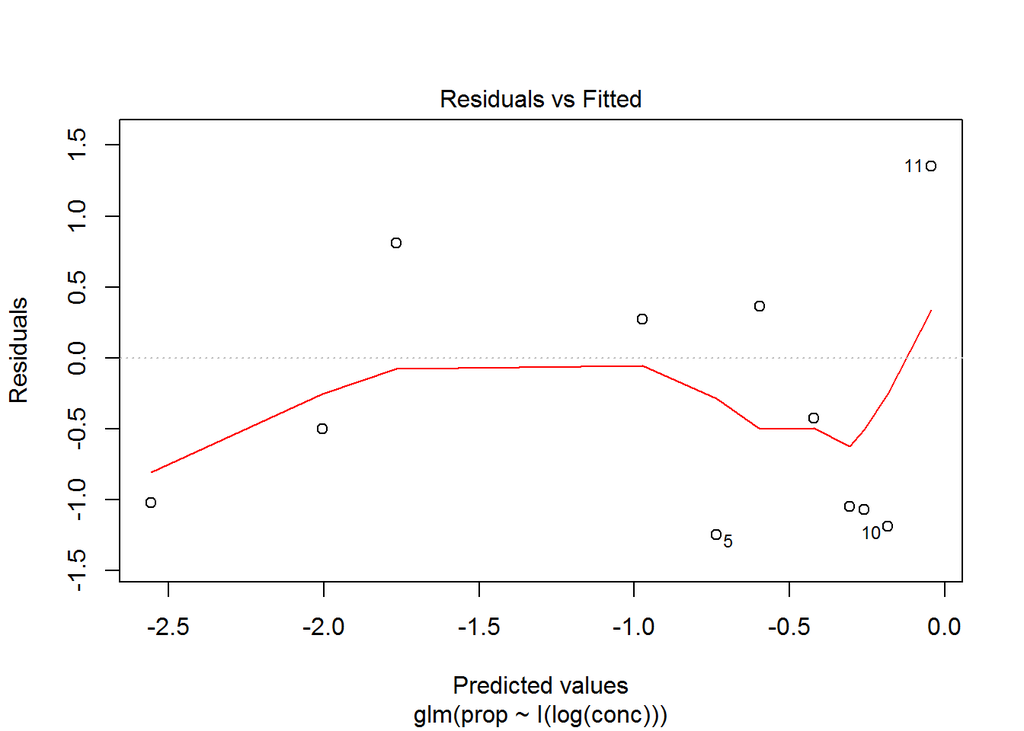

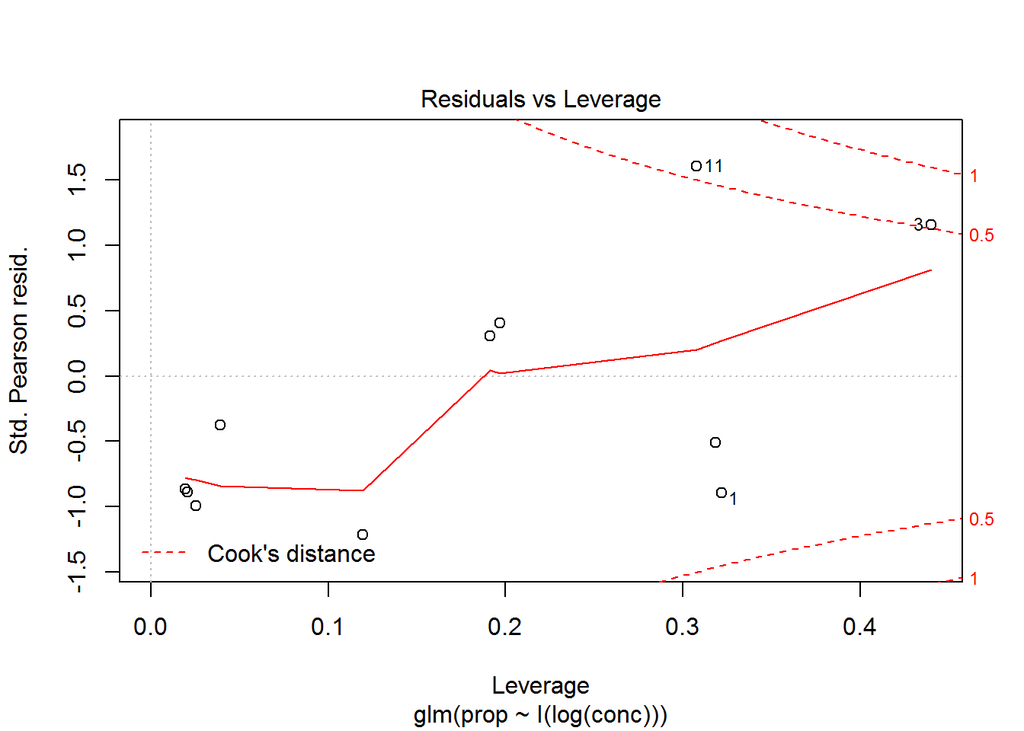

```r
plot(fit.log, which = c(1, 5))
```

Outliers are now less of an issue.

9. The `moths` data frame in the `DAAG` package contains data from a study of the effect of habitat on the densities of two species of moth (A and P). The quasipoisson distribution is a reasonable model for these data. Try modeling the variable `A` using this distribution. Is there a better link function than the standard?

```r
A.glm <- glm(formula = A ~ log(meters) + factor(habitat), family =
quasipoisson, data = moths)
summary(A.glm)
```

```
##
## Call:
## glm(formula = A ~ log(meters) + factor(habitat), family = quasipoisson,
##     data = moths)
##
## Deviance Residuals:
##     Min       1Q   Median       3Q      Max
## -3.5562  -1.4635  -0.0007   0.9248   3.0822
##
## Coefficients:
##                           Estimate Std. Error t value Pr(>|t|)
## (Intercept)               -15.6958  2096.5884  -0.007    0.994
## log(meters)                 0.1292     0.1528   0.845    0.404
## factor(habitat)Disturbed   15.6224  2096.5885   0.007    0.994
## factor(habitat)Lowerside   16.9057  2096.5884   0.008    0.994
## factor(habitat)NEsoak      16.0840  2096.5884   0.008    0.994
## factor(habitat)NWsoak      18.4681  2096.5884   0.009    0.993
## factor(habitat)SEsoak      16.9677  2096.5884   0.008    0.994
## factor(habitat)SWsoak      17.1371  2096.5884   0.008    0.994
## factor(habitat)Upperside   16.7433  2096.5884   0.008    0.994
##
## (Dispersion parameter for quasipoisson family taken to be 2.700801)
##
##     Null deviance: 257.108  on 40  degrees of freedom
## Residual deviance:  93.991  on 32  degrees of freedom
## AIC: NA
##
## Number of Fisher Scoring iterations: 13
```

```r
# Note the huge standard errors

## Consider the square root link as another possibility
A2.glm <- glm(formula = A ~ sqrt(meters) + factor(habitat), family = quasipoisson(link=sqrt), data = moths)
summary(A2.glm)
```

```
##
## Call:
## glm(formula = A ~ sqrt(meters) + factor(habitat), family = quasipoisson(link = sqrt),
##     data = moths)
##
## Deviance Residuals:
##     Min       1Q   Median       3Q      Max
## -3.4926  -1.4380  -0.0179   0.8694   3.0841
##
## Coefficients:
##                          Estimate Std. Error t value Pr(>|t|)
## (Intercept)              -0.26974    0.88037  -0.306   0.7613
## sqrt(meters)              0.05893    0.06886   0.856   0.3985
## factor(habitat)Disturbed  1.18451    0.89161   1.329   0.1934
## factor(habitat)Lowerside  2.18034    0.86816   2.511   0.0173 *
## factor(habitat)NEsoak     1.41339    0.89452   1.580   0.1239
## factor(habitat)NWsoak     4.86203    0.94902   5.123 1.39e-05 ***
## factor(habitat)SEsoak     2.27990    0.87891   2.594   0.0142 *
## factor(habitat)SWsoak     2.49185    0.95407   2.612   0.0136 *
## factor(habitat)Upperside  1.83905    1.09824   1.675   0.1038
## ---
## Signif. codes:  0 '***' 0.001 '**' 0.01 '*' 0.05 '.' 0.1 ' ' 1
##
## (Dispersion parameter for quasipoisson family taken to be 2.701906)
##
##     Null deviance: 257.108  on 40  degrees of freedom
## Residual deviance:  93.741  on 32  degrees of freedom
## AIC: NA
##
## Number of Fisher Scoring iterations: 10
```

10. Let’s try to specify our own link function: $f(x) = \log(\exp(x)-1)$. Generate data like this:

```r
n <- 1000
x <- runif(n)
sh <- 2
y <- rgamma(n,scale=log(2+3*x)/sh,shape=sh)
```

Specify the link function and run a `glm` regressing `y` on `x`. **Hint:** Look at the help file for `family`. You need to make an object of type “link-glm”, containing the items needed for `glm` to run: a link function, an inverse link, the derivative of the inverse link, and a function that describes the domain of the inverse link.

```r
 ## link
 linkfun <- function(y) log(exp(y)-1)
 ## inverse link
 linkinv <- function(eta)  log(exp(eta)+1)
 ## derivative of invlink wrt eta
 mu.eta <- function(eta) { 1/(exp(-eta) + 1) }
 valideta <- function(eta) TRUE
 link <- "log(exp(y)-1)"
 vv <- structure(list(linkfun = linkfun, linkinv = linkinv,
                 mu.eta = mu.eta, valideta = valideta,
                 name = link),
                 class = "link-glm")

glm(y~x,family=Gamma(link=vv))
```

```
##
## Call:  glm(formula = y ~ x, family = Gamma(link = vv))
##
## Coefficients:
## (Intercept)            x
##      0.2316       1.2625
##
## Degrees of Freedom: 999 Total (i.e. Null);  998 Residual
## Null Deviance:       573.3
## Residual Deviance: 533.4     AIC: 2145
```

End of Practical